# dplyr and tidyr ps1

Lucy Zhang

January 25, 2015

This is problem set #1, in which we hope you will practice the packages tidyr and dplyr. There are some great cheat sheets from [RStudio](http://www.rstudio.com/resources/cheatsheets/).

## The data set

This data set comes from a replication of [Janiszewski and Uy (2008)](http://dx.doi.org/10.1111/j.1467-9280.2008.02057.x), who investigated whether the precision of the anchor for a price influences the amount of adjustment.

In the data frame, the `Input.condition` variable represents the experimental condition (under the rounded anchor, the rounded anchor, over the rounded anchor). `Input.price1`, `Input.price2`, and `Input.price3` are the anchors for the `Answer.dog_cost`, `Answer.plasma_cost`, and `Answer.sushi_cost` items.

## Preliminaries

Done

```r
library(ggplot2)
library(reshape2)
library(bootstrap)
library(lme4)
library(stringr)
library(lubridate)
library(plyr) # first load plyr then dplyr from https://github.com/hadley/dplyr
library(dplyr)
library(tidyr)
```

## Part 1: Data cleaning

```r
d <- read.csv("/Users/lucyzhang/psych254_lucy/data/janiszewski_rep_exercise.csv")
```

## Part 2: Making these data tidy

Now let’s start with the cleaned data, so that we are all beginning from the same place.

```r
d <- read.csv("/Users/lucyzhang/psych254_lucy/data/janiszewski_rep_cleaned.csv")


d.tidy<-select(d, WorkerId, Input.price1, Input.price2, Input.price3, Input.condition, Answer.dog_cost, Answer.plasma_cost, Answer.sushi_cost)
```

Renaming variables

```r
d.tidy<-rename(d.tidy, sushi=Answer.sushi_cost)
d.tidy<-rename(d.tidy, condition=Input.condition)
d.tidy<-rename(d.tidy, price1=Input.price1); d.tidy<-rename(d.tidy, price2=Input.price2); d.tidy<-rename(d.tidy, price3=Input.price3)
d.tidy<-rename(d.tidy, dog=Answer.dog_cost); d.tidy<-rename(d.tidy, plasma=Answer.plasma_cost)
d.tidy2<-select(d.tidy, WorkerId, condition, dog, plasma, sushi)
```

Gather

```r
d.tidy3<-gather(d.tidy2, item, answerprice, -condition, -WorkerId)
```

Spread

```r
d.wide <- spread(d.tidy3, item, answerprice)
```

## Part 3: Manipulating the data using dplyr

```r
d.raw <- read.csv("/Users/lucyzhang/psych254_lucy/data/janiszewski_rep_exercise.csv")
d.unique.subs<-distinct(d.raw, WorkerId)
```

Graphs

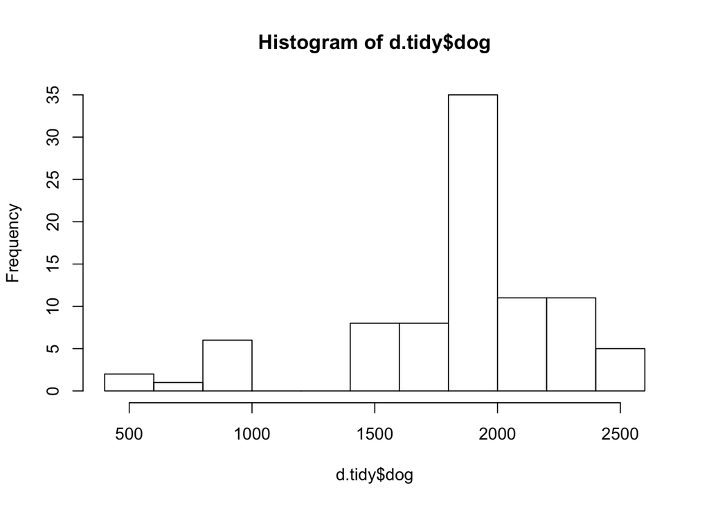

```r
hist(d.tidy$dog)
```

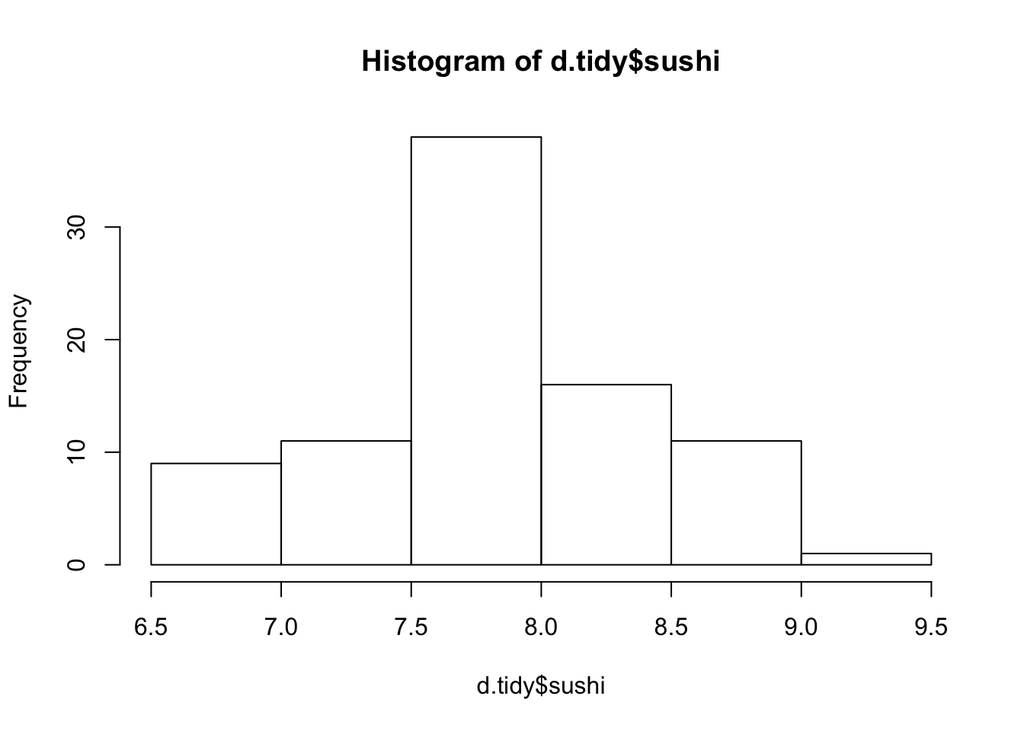

```r
hist(d.tidy$sushi)
```

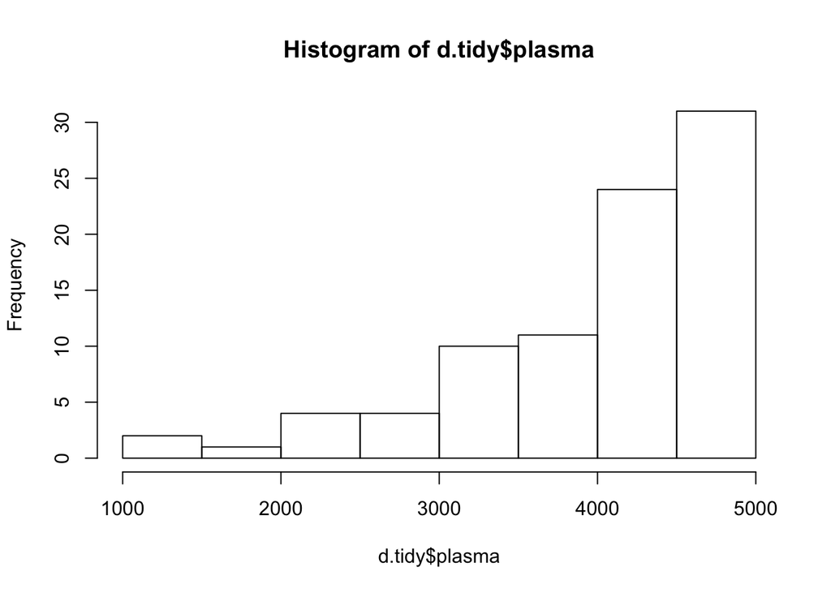

```r
hist(d.tidy$plasma)
```

Summarise

```r
summarise(d.tidy2, dog=sum(dog))
```

```
##      dog
## 1 164994
```

```r
summarise(d.tidy2, dog=mean(dog))
```

```
##        dog
## 1 1896.483
```

```r
summarise(d.tidy2, plasma=mean(plasma))
```

```
##     plasma
## 1 4140.023
```

```r
summarise(d.tidy2, sushi=mean(sushi, na.rm=TRUE))
```

```
##      sushi
## 1 8.009884
```

Group_by

```r
d.tidy3 %>%
  group_by(item, na.rm=TRUE) %>%
  summarise(price=mean(answerprice, na.rm=TRUE))
```

```
## Source: local data frame [3 x 3]
## Groups: item
##
##     item na.rm       price
## 1    dog  TRUE 1896.482644
## 2 plasma  TRUE 4140.022874
## 3  sushi  TRUE    8.009884
```

The expression we were given

```r
d.tidy <- d %>%
  select(WorkerId, Input.condition,
         starts_with("Answer"),
         starts_with("Input")) %>%
  rename(workerid = WorkerId,
         condition = Input.condition,
         plasma_anchor = Input.price1,
         dog_anchor = Input.price2,
         sushi_anchor = Input.price3,
         dog_cost = Answer.dog_cost,
         plasma_cost = Answer.plasma_cost,
         sushi_cost = Answer.sushi_cost) %>%
  gather(name, cost,
         dog_anchor, plasma_anchor, sushi_anchor,
         dog_cost, plasma_cost, sushi_cost) %>%
  separate(name, c("item", "type"), sep = "_") %>%
  spread(type, cost)
```

- By computing absolute value of percentage change in price, and

```r
pcts <- d.tidy %>%
  mutate(pct_change = abs((anchor-cost)/anchor)) %>%
  group_by(condition) %>%
  group_by(item, add=TRUE) %>%
  summarize(pct_change=mean(pct_change, na.rm=TRUE))

chisq.test(pcts$pct_change)
```

```
##
##  Chi-squared test for given probabilities
##
## data:  pcts$pct_change
## X-squared = 0.157, df = 8, p-value = 1
```

Z-scores

To do the second, you will need to `group` first by item, compute z-scores with respect to items, then further group by condition.

HINT: `scale(x)` returns a complicated data structure that doesn’t play nicely with dplyr. try `scale(x)[,1]` to get what you need.

HINT: by default, `group_by` undoes any previous groupings. If you want to add new grouping variables *on top* of pre-existing ones, specify `add = TRUE`, e.g., `d %>% group_by(var1) %>% group_by(var2, add = TRUE)`.

```r
z.scores <- d.tidy %>%
  group_by(item) %>%
  mutate(z=scale(cost)[,1]) %>%
  group_by(condition, add=TRUE) %>%
  summarize(z=mean(z, na.rm=TRUE))
```

Graphing

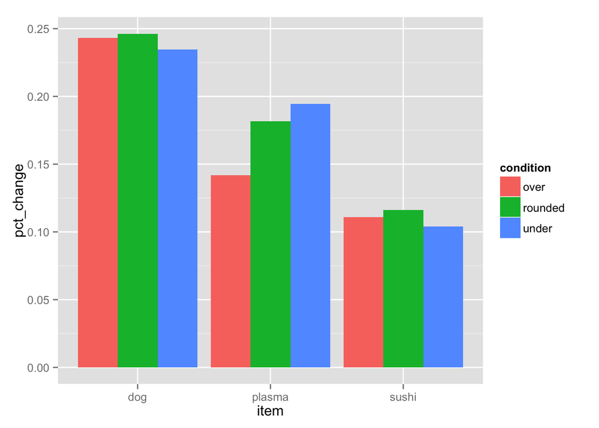

```r
qplot(item, pct_change, fill=condition,
      position="dodge",
      stat="identity", geom="bar",
      data=pcts)
```

and the z-scores:

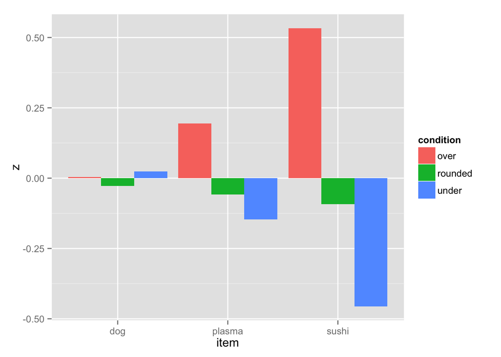

```r
qplot(item, z, fill=condition,
      position="dodge",
      stat="identity", geom="bar",
      data=z.scores)
```

Oh well. This replication didn’t seem to work out straightforwardly.